# Assignment 6

2026-03-02

1. Load the NHANES data using the NHANES R package

```r
data(NHANES) # initialize data

str(NHANES) # briefly examine what we have
```

```
## tibble [10,000 × 76] (S3: tbl_df/tbl/data.frame)
##  $ ID              : int [1:10000] 51624 51624 51624 51625 51630 51638 51646 51647 51647 51647 ...
##  $ SurveyYr        : Factor w/ 2 levels "2009_10","2011_12": 1 1 1 1 1 1 1 1 1 1 ...
##  $ Gender          : Factor w/ 2 levels "female","male": 2 2 2 2 1 2 2 1 1 1 ...
##  $ Age             : int [1:10000] 34 34 34 4 49 9 8 45 45 45 ...
##  $ AgeDecade       : Factor w/ 8 levels " 0-9"," 10-19",..: 4 4 4 1 5 1 1 5 5 5 ...
##  $ AgeMonths       : int [1:10000] 409 409 409 49 596 115 101 541 541 541 ...
##  $ Race1           : Factor w/ 5 levels "Black","Hispanic",..: 4 4 4 5 4 4 4 4 4 4 ...
##  $ Race3           : Factor w/ 6 levels "Asian","Black",..: NA NA NA NA NA NA NA NA NA NA ...
##  $ Education       : Factor w/ 5 levels "8th Grade","9 - 11th Grade",..: 3 3 3 NA 4 NA NA 5 5 5 ...
##  $ MaritalStatus   : Factor w/ 6 levels "Divorced","LivePartner",..: 3 3 3 NA 2 NA NA 3 3 3 ...
##  $ HHIncome        : Factor w/ 12 levels " 0-4999"," 5000-9999",..: 6 6 6 5 7 11 9 11 11 11 ...
##  $ HHIncomeMid     : int [1:10000] 30000 30000 30000 22500 40000 87500 60000 87500 87500 87500 ...
##  $ Poverty         : num [1:10000] 1.36 1.36 1.36 1.07 1.91 1.84 2.33 5 5 5 ...
##  $ HomeRooms       : int [1:10000] 6 6 6 9 5 6 7 6 6 6 ...
```

[output cut: 62 more lines]

2. Restrict the NHANES data to the list of 11 variables below. Partition the data into training and testing using a 70/30 split. Perform light data cleaning. Determine if you want to exclude any of the features before you start.

“Age”, “Race1”, “Education”, “HHIncome”, “Weight”, “Height”, “Pulse”, “Diabetes”, “BMI”, “PhysActive”, “Smoke100”

```r
# filter data, clean names
# exclude weight and height due to multicollinearity with bmi
NHANES <- NHANES |>
  janitor::clean_names() |>
  select(age, race1, education, hh_income, pulse, diabetes, bmi, phys_active, smoke100) |> drop_na()

# Centering and Scaling
set.up.preprocess <- preProcess(NHANES , method = c("center", "scale"))

# Output pre-processed values
transformed.vals <- predict(set.up.preprocess, NHANES)

# Creating balanced partitions in the data
train.index <- createDataPartition(NHANES$diabetes, p = 0.7, list = FALSE)

nhanes.train <- NHANES[train.index, ]
nhanes.test <- NHANES[-train.index, ]

summary(NHANES$diabetes)
```

```
##   No  Yes
## 5697  659
```

```r
summary(nhanes.train$diabetes)
```

```
##   No  Yes
## 3988  462
```

```r
summary(nhanes.test$diabetes)
```

```
##   No  Yes
## 1709  197
```

I excluded weight and height due to multicollinearity between the predictors with BMI. We split training and test data in 70/30 partitions by diabetes status.

3. Construct three prediction models to predict diabetes using the features from NHANES. You will optimize each model using cross-validation to choose hyperparameters in the training data and then compare performance across models. You will use the following three algorithms to create your prediction models:
1. Classification Tree

```r
set.seed(123)

# 10-fold cross-validation and using down-sampling because of imbalance in data
train.control.class<-trainControl(method="cv", number=10, sampling="down")

# sequence of cp parameters to try
grid.1<-expand.grid(cp=seq(0.001, 0.3, by=0.01))

# train model
tree.nhanes <-train(
                      diabetes~.,
                      data=nhanes.train,
                      method="rpart",
                      trControl=train.control.class,
                      tuneGrid=grid.1
                      )

tree.nhanes$bestTune
```

```
##      cp
## 1 0.001
```

```r
tree.nhanes
```

```
## CART
##
## 4450 samples
##    8 predictor
##    2 classes: 'No', 'Yes'
##
## No pre-processing
## Resampling: Cross-Validated (10 fold)
## Summary of sample sizes: 4005, 4005, 4004, 4005, 4005, 4006, ...
## Addtional sampling using down-sampling
##
## Resampling results across tuning parameters:
##
##   cp     Accuracy   Kappa
##   0.001  0.7078514  0.2308115
##   0.011  0.6647037  0.2079888
##   0.021  0.6332430  0.1807996
##   0.031  0.6269443  0.1769780
##   0.041  0.6090081  0.1640054
##   0.051  0.5793452  0.1431098
##   0.061  0.5793452  0.1431098
##   0.071  0.5793452  0.1431098
##   0.081  0.5793452  0.1431098
##   0.091  0.5793452  0.1431098
##   0.101  0.5793452  0.1431098
##   0.111  0.5793452  0.1431098
##   0.121  0.5793452  0.1431098
##   0.131  0.5793452  0.1431098
##   0.141  0.5793452  0.1431098
##   0.151  0.5793452  0.1431098
##   0.161  0.5793452  0.1431098
##   0.171  0.5793452  0.1431098
##   0.181  0.5793452  0.1431098
##   0.191  0.5793452  0.1431098
##   0.201  0.5793452  0.1431098
##   0.211  0.5793452  0.1431098
##   0.221  0.5793452  0.1431098
##   0.231  0.5793452  0.1431098
##   0.241  0.5793452  0.1431098
##   0.251  0.5793452  0.1431098
##   0.261  0.5793452  0.1431098
##   0.271  0.5793452  0.1431098
##   0.281  0.5793452  0.1431098
##   0.291  0.5793452  0.1431098
##
## Accuracy was used to select the optimal model using the largest value.
## The final value used for the model was cp = 0.001.
```

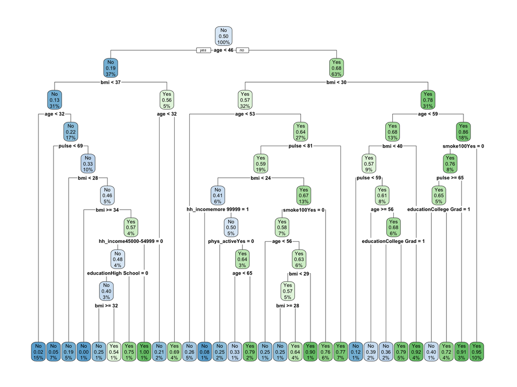

```r
tree.nhanes$finalModel %>%
  rpart.plot()
```

```r
# obtain variable importance on the final model within training data
varImp(tree.nhanes)
```

```
## rpart variable importance
##
##   only 20 most important variables shown (out of 36)
##
##                        Overall
## age                   100.0000
## bmi                    66.1311
## pulse                  26.0073
## educationCollege Grad  25.9348
## hh_incomemore 99999    19.4667
## phys_activeYes         12.6279
## race1White              5.0494
## race1Mexican            4.6393
## smoke100Yes             4.2695
## hh_income45000-54999    3.6509
## hh_income65000-74999    2.0205
## hh_income55000-64999    1.9376
## race1Hispanic           1.3287
## hh_income35000-44999    1.3101
## educationHigh School    1.1938
## educationSome College   0.8119
## hh_income10000-14999    0.7489
## hh_income 5000-9999     0.5465
## hh_income15000-19999    0.4811
## race1Other              0.4501
```

```r
# accuracy metric and confusion matrix from training
confusionMatrix(tree.nhanes)
```

```
## Cross-Validated (10 fold) Confusion Matrix
##
## (entries are percentual average cell counts across resamples)
##
##           Reference
## Prediction   No  Yes
##        No  62.8  2.4
##        Yes 26.8  8.0
##
##  Accuracy (average) : 0.7079
```

The CART model was trained with 10-fold cross-validation, yielding a final value of 0.001 for the complexity parameter $Cp$ and an average accuracy of 70.8% (based on the confusion matrix).